# Visual Search Demo

Data from real visual search tasks.

```r
data <- read.table("PSYC6229_search_data.csv", header = TRUE, sep = ",")
summary(subset(data, Condition == "2_vs_5"))
```

```
    Subject           Condition         Trial
 6      : 4016   2_vs_5    :35867   Min.   :  1.0
 7      : 4000   R_vs_G    :    0   1st Qu.: 75.0
 2      : 3997   RV_vs_RHGV:    0   Median :151.0
 9      : 3997                      Mean   :155.1
 4      : 3995                      3rd Qu.:229.0
 1      : 3993                      Max.   :700.0
 (Other):11869
    Setsize          Tpresent          Error
 Min.   : 3.000   Min.   :0.0000   Min.   :0.00000
 1st Qu.: 6.000   1st Qu.:0.0000   1st Qu.:0.00000
 Median : 6.000   Median :0.0000   Median :0.00000
 Mean   : 9.733   Mean   :0.4967   Mean   :0.02967
 3rd Qu.:12.000   3rd Qu.:1.0000   3rd Qu.:0.00000
 Max.   :18.000   Max.   :1.0000   Max.   :1.00000

   Type             RT
 FA  :  254   Min.   :   0
 HIT :17005   1st Qu.: 704
 MISS:  810   Median :1028
 TNEG:17798   Mean   :1263
              3rd Qu.:1627
              Max.   :8407
```

We plot reaction times, columns are set sizes and rows are the different conditions

We add ‘& data < 2000’ to remove some very obv. outliers

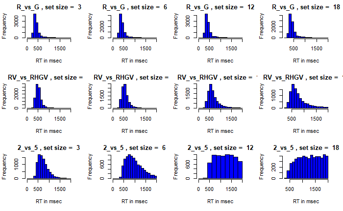

```r
par(mfrow=c(3,4))
for (i in unique(data$Condition)) {
  for (j in sort(unique(data$Setsize))) {
    hist(data$RT[data$Condition==i & data$Setsize==j & data$RT < 2000],
         xlab="RT in msec",
         main=paste(i,", set size = ",j),
         col="blue")
  }
}
```

### Pattern of errors

```r
aggregate(data$Error, list(data$Condition,data$Setsize), mean)
```

| Group.1 | Group.2 | x |
| --- | --- | --- |
| 2_vs_5 | 3 | 0.01815940 |
| R_vs_G | 3 | 0.01859586 |
| RV_vs_RHGV | 3 | 0.02044480 |
| 2_vs_5 | 6 | 0.01586427 |
| R_vs_G | 6 | 0.01783724 |
| RV_vs_RHGV | 6 | 0.02042860 |
| 2_vs_5 | 12 | 0.03257474 |
| R_vs_G | 12 | 0.01602725 |
| RV_vs_RHGV | 12 | 0.02118812 |
| 2_vs_5 | 18 | 0.05233015 |

[output cut: 2 more lines]

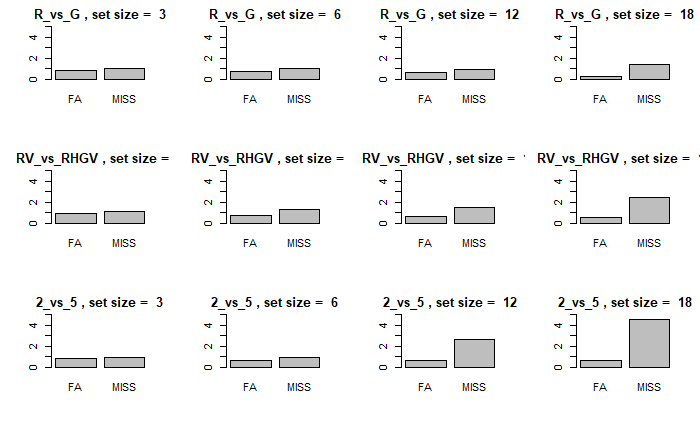

```r
dev.new()
par(mfrow=c(3,4))
for (i in unique(data$Condition)) {
  for (j in sort(unique(data$Setsize))) {
    tmp <- data$Type[data$Condition==i & data$Setsize==j]
    counts <- table(tmp)
    barplot(100*counts[c("FA","MISS")]/sum(counts),
            ylim = c(0,5),
            main=paste(i,", set size = ",j))
  }
}
```

Note: the miss rates are the ones that increase was setsize + condition gets harder

### Patern of errors by subjects

This is how you would plot for a paper

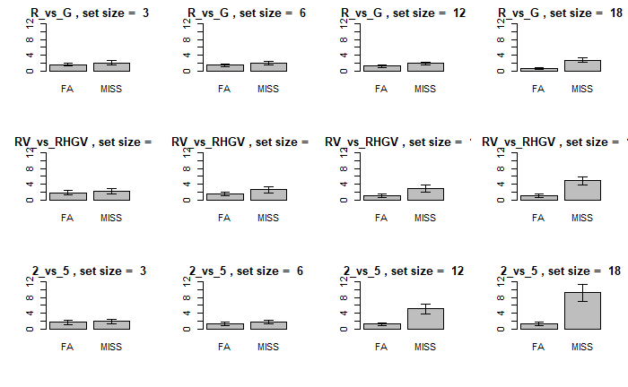

```r
par(mfrow=c(3,4))
for (i in unique(data$Condition)) {
  for (j in sort(unique(data$Setsize))) {
    tmp <- data[data$Condition==i & data$Setsize==j,]
    bySub <- aggregate(tmp$Error, list(tmp$Subject,tmp$Tpresent), mean)
    meansBySub <- aggregate(bySub$x, list(bySub$Group.2), mean)
    means <- 100 * meansBySub$x
    sds <- aggregate(bySub$x, list(bySub$Group.2), sd)
    sderr <- 100 * sds$x / sqrt(length(unique(bySub$Group.1)))
    barHeights <- barplot(means, names.arg = list("FA","MISS"),
                          ylim = c(0,12), main=paste(i,", set size = ",j))
    arrows(barHeights, means - sderr, barHeights, means + sderr,
           lwd = 1.5, angle = 90, code = 3, length = 0.05)
  }
}
```

Note that error bars are just lines (arrows?) that are drawn on top of the plot.

### d’ by subjects

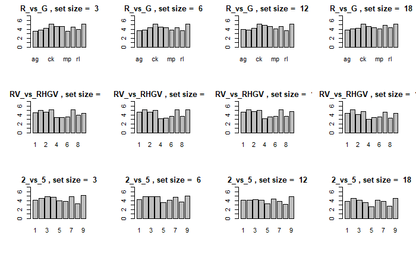

```r
par(mfrow=c(3,4))
for (i in unique(data$Condition)) {
  for (j in sort(unique(data$Setsize))) {
    tmp <- data[data$Condition==i & data$Setsize==j,]
    bySub <- aggregate(tmp$Error,
                       list(tmp$Subject,tmp$Tpresent), mean)
    bySub$x[bySub$x < 0.005] <- 0.005
    bySub$x[bySub$x > 0.995] <- 0.995
    zHIT <- qnorm(1-bySub$x[bySub$Group.2==1])
    zFA <- qnorm(bySub$x[bySub$Group.2==0])
    dprimeBySub <- zHIT - zFA
    barHeights <- barplot(dprimeBySub,
                          names.arg = unique(bySub$Group.1),
                          ylim = c(0,7),
                          main=paste(i,", set size = ",j))
  }
}
```

### Back to reaction times

Are these distributions normal?

```r
p <- matrix(ncol=5, nrow=4*29*2)
colnames(p) <- list("cond", "setsize", "subject", "tpres", "pval")
counter <- 1
for (i in unique(data$Condition)) {
  for (j in sort(unique(data$Setsize))) {
    for (ii in unique(data$Subject[data$Condition==i & data$Setsize==j])) {
      for (jj in unique(data$Tpresent)) {
        tmp <- data[data$Condition==i & data$Setsize==j & data$Subject==ii & data$Tpresent==jj,]
        result <- shapiro.test(tmp$RT)
        p[counter,] <- c(i, j, ii, jj, result$p.value)
        counter <- counter + 1
        }}}}
testresults = as.data.frame(p)
View(testresults)
```

Above: We do a shapiro-wilk’s test for non-normality.  
We get really small pvals (so the test is significant for all subjects)… SO they are NOT normal.

What can we do? One option: **trim the data!**.  
We just get rid of all that data that’s above/below some sd and assume it is gaussian. This introduces some bias, but it’s easy

```r
flag <- 1
for (i in unique(data$Condition)) {
  for (j in sort(unique(data$Setsize))) {
    for (ii in unique(data$Subject[data$Condition==i & data$Setsize==j])) {
      for (jj in unique(data$Tpresent)) {
        tmp <- data[data$Condition==i & data$Setsize==j & data$Subject==ii & data$Tpresent==jj,]
        thHigh <- mean(tmp$RT) + (2.5*sd(tmp$RT))
        thLow <- mean(tmp$RT) - (2.5*sd(tmp$RT))
        new <- tmp[tmp$RT > thLow & tmp$RT < thHigh,]
        if (flag==1) {
          data2 <- new
          flag <- 0 }
        else {
          data2 <- rbind(data2, new) }
      }}}}
dataOld <- data
data <- data2
```

This new data file gets rid of all the rts that are long basically.  
We can now use the trimmed data and look at it using all our previous code if we want.  
Note that it’s still not normally distributed, but it’s better.

### Search slopes

```r
x <- sort(unique(data$Setsize))
for (i in unique(data$Condition)) {
  dev.new()
  tmp <- data[data$Condition==i,]
  bySub <- aggregate(tmp$RT,
                     list(tmp$Subject,tmp$Tpresent,tmp$Setsize), mean)
  means <- aggregate(bySub$x,
                     list(bySub$Group.2, bySub$Group.3), mean)
  means <- means[order(means$Group.2),]
  y0 = means$x[means$Group.1==0]  # means for the target absent condition
  y1 = means$x[means$Group.1==1]  # means for the target present condition
  plot(x, y0, col="blue", ylim=c(0,2500),
       xlab="Set size", ylab="RT (ms)", main=i)
  points(x, y1, col="red")
  regressline <- lm(y0 ~ x)
  abline(regressline)
}
```

Note: plot these.

# Demo 2: Signal Detection Theory simulation

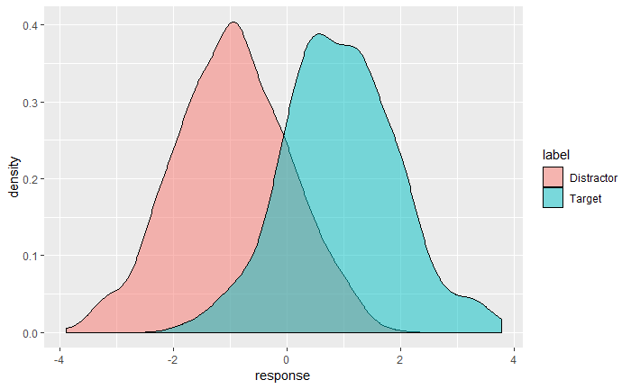

```r
library(ggplot2)
dprime <- 2
targs <- data.frame(response=rnorm(500, mean=(dprime/2), sd=1))
dists <- data.frame(response=rnorm(500, mean=(-dprime/2), sd=1))
targs$label <- "Target"
dists$label <- "Distractor"
stimuli <- rbind(targs,dists)
ggplot(stimuli, aes(response, fill=label)) +
  geom_density(alpha=0.5)
```

### Maximum Rule

```r
dprime <- 2
setsize <- 18
targs <- matrix(ncol=1, nrow=500)
dists <- matrix(ncol=1, nrow=500)
```

We then simulate a maximum rule observer.  
We draw targets and distractors.

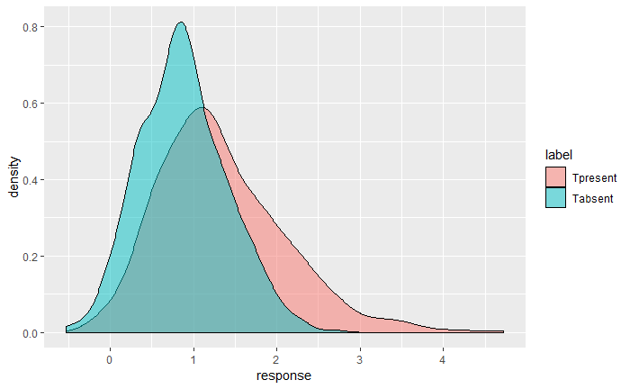

```r
counter <- 1
while (counter <= nrow(targs)) {
  nitems <- setsize
  tsample <- c(rnorm(1, mean=(dprime/2), sd=1),
               rnorm(nitems-1, mean=(-dprime/2), sd=1))
  dsample <- rnorm(nitems, mean=(-dprime/2), sd=1)
  targs[counter,] <- max(tsample)
  dists[counter,] <- max(dsample)
  counter <- counter+1
}
targs <- data.frame(response=targs, label="Tpresent")
dists <- data.frame(response=dists, label="Tabsent")
stimuli <- rbind(targs,dists)
ggplot(stimuli, aes(response, fill=label)) +
  geom_density(alpha=0.5)
```

### Maximum Role over set sizes

```r
dprime <- 2
setsize <- c(3,6,12,18)
targs <- matrix(ncol=4, nrow=500)
dists <- matrix(ncol=4, nrow=500)
for (i in 1:length(setsize)) {
  counter <- 1
  nitems <- setsize[i]
  while (counter <= nrow(targs)) {
    tsample <- c(rnorm(1, mean=(dprime/2), sd=1),
                 rnorm(nitems-1, mean=(-dprime/2), sd=1))
    dsample <- rnorm(nitems, mean=(-dprime/2), sd=1)
    targs[counter,i] <- max(tsample)
    dists[counter,i] <- max(dsample)
    counter <- counter+1
  }
  targtmp <- data.frame(response=targs[,i], label="Tpresent")
  disttmp <- data.frame(response=dists[,i], label="Tabsent")
  stimuli <- rbind(targtmp,disttmp)
  ggp <- ggplot(stimuli, aes(response, fill=label)) +
    geom_density(alpha=0.5) +
    ggtitle(paste("Setsize = ",nitems))
  dev.new()
  print(ggp)
  ggp
}
```

## Accuracy over set size

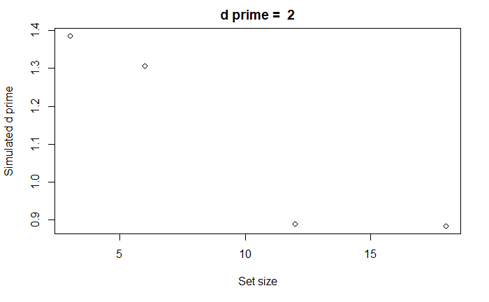

```r
diffMeans <- colMeans(targs) - colMeans(dists)
sds <- sqrt(( (apply(targs,2,sd)^2) + (apply(dists,2,sd)^2) ) / 2)
dSetsize <- diffMeans / sds
dev.new()
plot(setsize, dSetsize, xlab="Set size", ylab="Simulated d prime", main=paste("d prime = ",dprime))
```

## RT over set size

This is based on speed-accuracy trade-off and it’s pretty hand-wavy. This is very simplified.

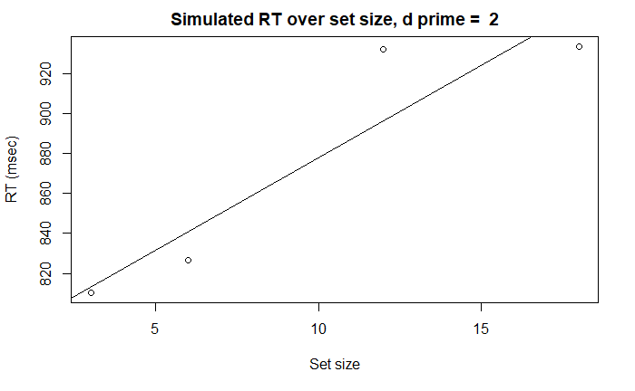

```r
nonsearchRT <- 400
beta <- 500
maxDprime <- 6.2
simulatedRT <- nonsearchRT + (beta * (1 - (log(dSetsize)/log(maxDprime))) )
dev.new()
plot(setsize, simulatedRT, xlab="Set size", ylab="RT (msec)",
     main=paste("Simulated RT over set size, d prime = ",dprime))
regressline <- lm(simulatedRT ~ setsize)
abline(regressline)
```

```r
summary(regressline)
```

```
Call:
lm(formula = simulatedRT ~ setsize)

Residuals:
      1       2       3       4
 -2.724 -14.355  35.520 -18.441

Coefficients:
            Estimate Std. Error t value Pr(>|t|)
(Intercept)  785.432     29.611   26.52  0.00142 **
setsize        9.257      2.615    3.54  0.07135 .
---
Signif. codes:  0 ‘***’ 0.001 ‘**’ 0.01 ‘*’ 0.05 ‘.’ 0.1 ‘ ’ 1

Residual standard error: 30.13 on 2 degrees of freedom
Multiple R-squared:  0.8624,    Adjusted R-squared:  0.7936
F-statistic: 12.53 on 1 and 2 DF,  p-value: 0.07135
```